# Duplex Sequencing Summary

## Table of Contents:

Top

1. Table of Contents
2. Glosary
3. Parameters
4. Consensus Maker Statistics
5. Family Size Plots
6. Read Statistics
7. Alignment Statistics
8. Consensus Making Ratios
9. BLAST Statistics
10. Insert Size Graph
11. Depth per Target
12. Muts per Cycle
13. Countmuts output

## Glosary:

Top

### Read:

A single DNA sequence; one half of an Illumina paired-end read.

### Paired-end read:

A pair of DNA sequences from the same molecule in the final library; analogous to cluster. Most sequencing facilities will refer to paired-end reads as reads.

### Family:

A group of reads originating from the same end of the same strand of the same original (pre-library preperation) DNA molecule.

### SSCS:

A consensus sequence made by comparing all reads in a family at each base, and selecting the most common base at each position for the consensus base if it matches the stringency requirement of what proportion of reads match the base.

### DCS:

A consensus made by comparing two SSCS from the same end of the same molecule; each SSCS molecule represents one strand of the molecule.

### Depth:

The number of DCS reads, present at a given position in the reference genome; equivalent to the number of original molecules sequenced.

## Parameters:

Top

| Parameter | Value |
| --- | --- |
| Version | 1.0.0 |
| RunID | test1 |
| Run Directory | testData |
| Inputs |  |
| R1 | testData/testSeq1.fastq.gz |
| R2 | testData/testSeq2.fastq.gz |
| Read Length | 150 |
| UMI Length | 8 |
| Spacer Length | 1 |
| Localization Length | 8 |
| Minimum family size | 3 |
| Maximum family size | 200 |
| Consensus Making Stringency | 0.7 |
| Max proportion Ns per DCS | 0.02 |
| Genome | /home/kohrnb/bioinformatics/dev/Duplex-Seq-Pipeline/test/testRef/testRef.fa |
| Bed File | /home/kohrnb/bioinformatics/dev/Duplex-Seq-Pipeline/test/testTarget/test.bed |
| Contaminant_filter DB | /home/kohrnb/bioinformatics/dev/Duplex-Seq-Pipeline/test/testBlastDb/testBlastDb |
| RGSM | test |
| RGLB | test |
| RGPL | test |
| RGPU | test |
| Clipping |  |
| 5' | 7 |
| 3' | 0 |

## Consensus Maker Statistics:

Top

```
Command: /home/kohrnb/bioinformatics/dev/Duplex-Seq-Pipeline/scripts/UnifiedConsensusMaker.py --input /dev/stdin --taglen 8 --spacerlen 1 --loclen 8 --write-sscs --prefix test1 --tagstats --cutoff 0.7 --Ncutoff 0.02 --numCores 4 --minmem 3 --maxmem 200
Started at Tuesday, 28. April 2020 01:37PM
Finished at Tuesday, 28. April 2020 01:37PM
7797 reads UMI processed
7796 reads processed
826 families processed
2 unrepresented families
0 families with family size < 3
0 families (DCS pairs) filtered for UMIs with mononucleotide repeats
826 SSCS made
0 SSCS filtered for excessive Ns
412 DCS made
2 DCS failed due to missing SSCS
0 DCS filtered for excessive Ns
```

### Family Size Plots:

Top

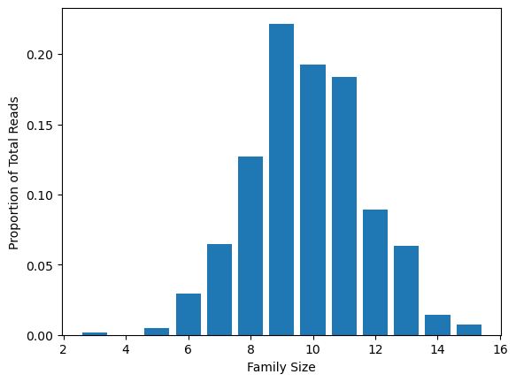

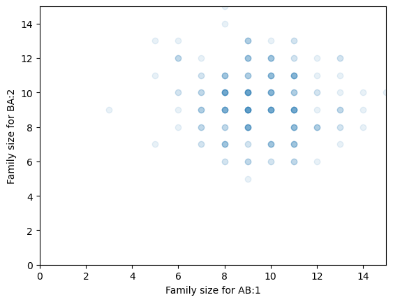

## Read Statistics:

Top

| Raw Reads | 7796 |
| --- | --- |
| SSCS Reads: | 828 |
| Mapped SSCS Reads: | 828 |
| DCS Reads: | 413 |
| Mapped DCS Reads: | 413 |

## Alignment Statistics:

Top

| Raw on target | 100.0% |
| --- | --- |
| SSCS Mapped | 100.0% |
| DCS Mapped | 100.0% |

## Consensus Making Ratios:

Top

| Raw/SSCS | 9.42 |
| --- | --- |
| SSCS/DCS | 2.0 |

## BLAST Statistics:

Top

### Species Composition:

To look up taxIDs, use [NCBI taxonomy](https://www.ncbi.nlm.nih.gov/taxonomy)

| TaxID | Number Reads |
| --- | --- |
| 9606 | 408 |
| 9544 | 2 |
| -1 | 2 |

### Ambiguity Composition:

```
# AMBIGUITY CLASSES:
#   -1: Missing 'am' tag
#   0: BLAST has 1 best match, matches bwa position
#   1: BLAST has 1 best match, does not match bwa position
#   2: BLAST has 2+ best matches, correct species
#   3: BLAST has 2+ best matches, at least one incorrect species
#   4: BLAST did not attempt alignment, or no blast matches
#   5: Not BLASTed

# Non-ambiguous file ambiguity class counts:
Class   Counts
0   3
1   0
2   0
3   0
4   0
5   401
-1  0

# Ambiguous file ambiguity class counts:
Class   Counts
0   0
1   0
2   4
3   0
4   0
5   0
-1  0
```

## Insert size graph:

Top

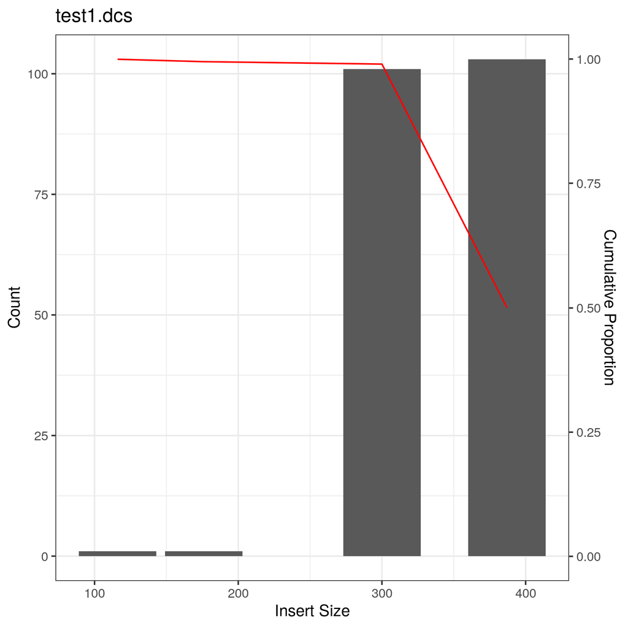

## Depth per Target:

Top

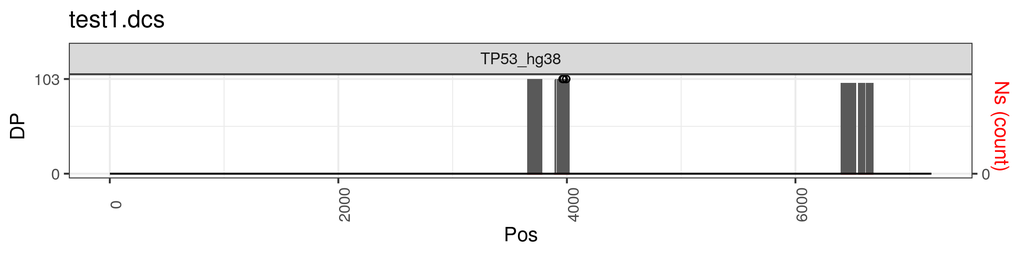

## Muts per Cycle:

Top

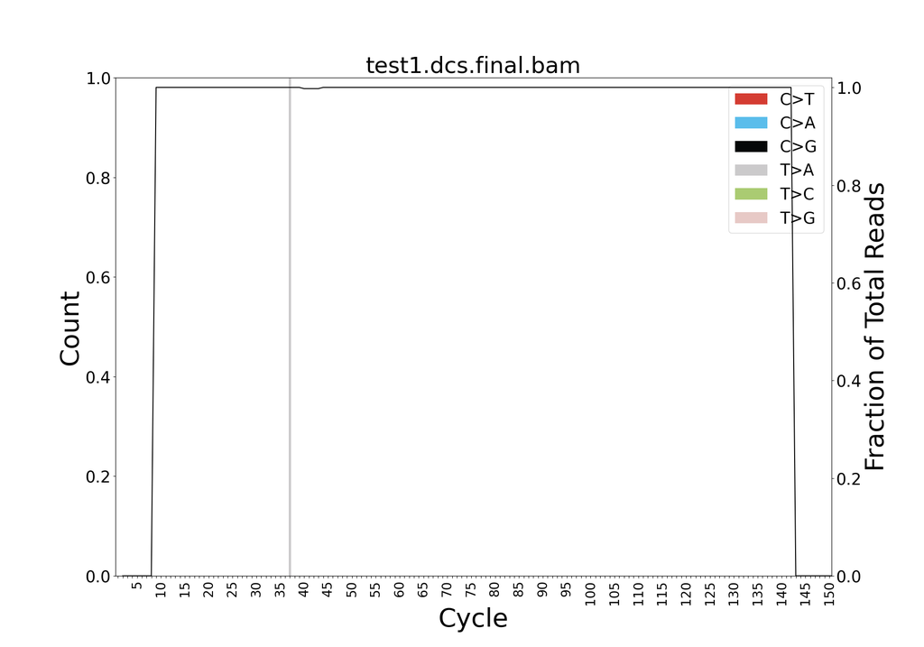

## Countmuts output:

Top

### Parameters:

| Parameter | Value |
| --- | --- |
| Input file | ../testData/Final/dcs/test1.dcs.final.bam |
| Input reference | /home/kohrnb/bioinformatics/dev/Duplex-Seq-Pipeline/test/testRef/testRef.fa |
| Input bed | /home/kohrnb/bioinformatics/dev/Duplex-Seq-Pipeline/test/testTarget/test.bed |
| Minimum Depth | 100 |
| Clonality | 0.0-0.1 |
| Unique | True |

### Overall Mutation Counts:

| MUTATION_TYPE | MUTATION_CLASS | COUNT | DENOMINATOR | FREQUENCY |
| --- | --- | --- | --- | --- |
| A>T | SNV | 0 | 8857 | 0.00e+00 |
| A>C | SNV | 0 | 8857 | 0.00e+00 |
| A>G | SNV | 0 | 8857 | 0.00e+00 |
| T>A | SNV | 1 | 7622 | 1.31e-04 |
| T>C | SNV | 0 | 7622 | 0.00e+00 |
| T>G | SNV | 0 | 7622 | 0.00e+00 |
| C>A | SNV | 0 | 5664 | 0.00e+00 |
| C>T | SNV | 0 | 5664 | 0.00e+00 |
| C>G | SNV | 0 | 5664 | 0.00e+00 |
| G>A | SNV | 0 | 5457 | 0.00e+00 |
| G>T | SNV | 0 | 5457 | 0.00e+00 |
| G>C | SNV | 0 | 5457 | 0.00e+00 |
| Total | SNV | 1 | 27600 | 3.62e-05 |
| +4 | INS | 1 | 27600 | 3.62e-05 |
| Total | INS | 1 | 27600 | 3.62e-05 |
| -4 | DEL | 1 | 27600 | 3.62e-05 |
| Total | DEL | 1 | 27600 | 3.62e-05 |